# Oomycete species associated with soybean seedlings in the U.S.

J. Alejandro Rojas

# Part I: identification and pathogenicity characterization

## Figures and analyses

**Figure 1.** Map of sampled soybean fields in 2011 and 2012, and intensity of planted soybean acres demonstrated by color intensity at the county/parish level.

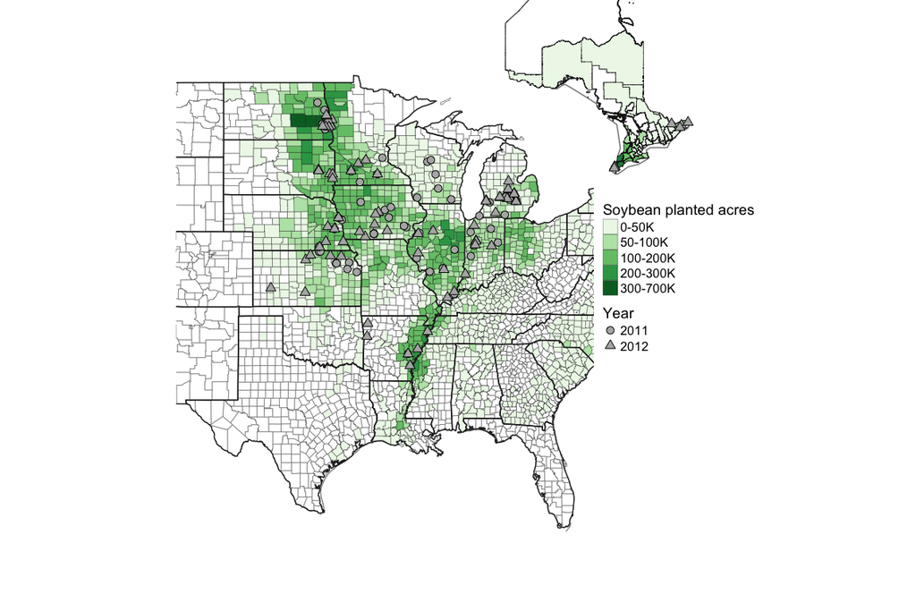

**Figure 2.** Frequency at which different Oomycete species were recovered from diseased soybean seedlings in 2011 and 2012. (*) Species previously reported as associated with soybean in the fungal-host database (http://nt.ars-grin.gov/fungaldatabases/fungushost/fungushost.cfm).

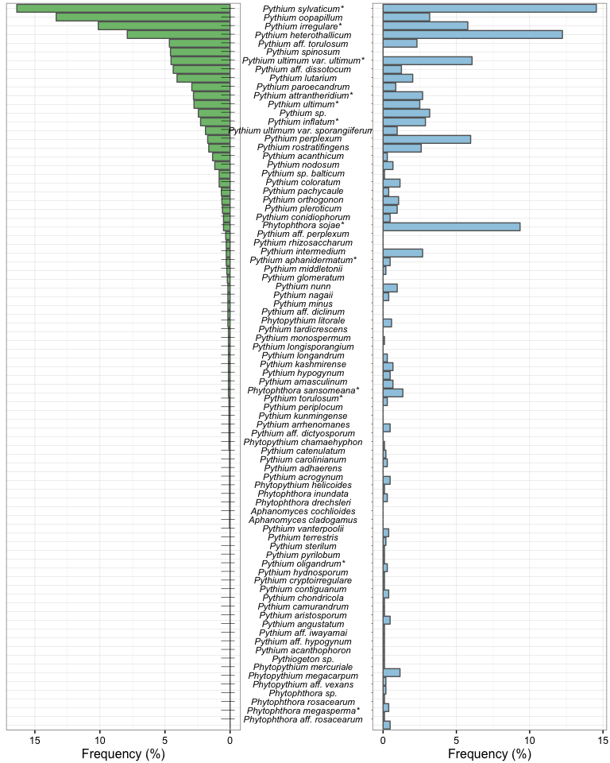

**Figure 3.** Frequency of the oomycete species summarized by clade for 2011 and 2012. Oomycete genera outside of Pythium and Phytophthora were summarized by genus. Those species designated as spp. are not well resolved based only on the ITS sequence.

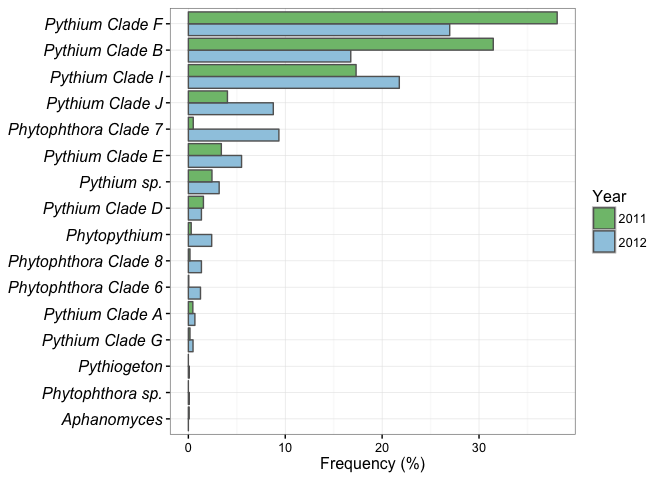

For **seed rot analyses** in detail, please check the seed_rot_data_analysis

**Figure 4.** Mean disease severity index of 84 oomycete species screened in a seed rot assay at 13ºC and 20ºC. Bars represent standard error and disease severity index values from 0 = non-pathogenic to 100 = highly pathogenic.

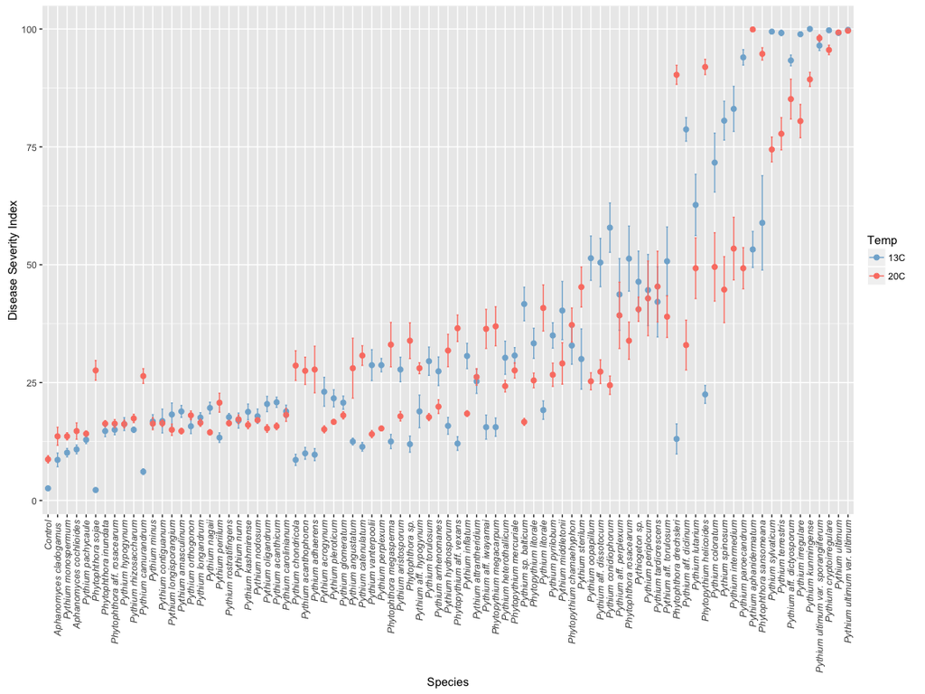

**Figure 5.** (A) Hierarchical analysis of the disease severity index of 84 oomycete species to establish three clusters related to pathogenicity on soybean and (B) boxplot of disease severity index by clusters at 13°C and 20°C as evaluated in a seed rot assay.

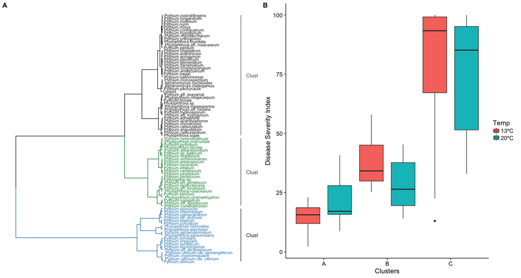

For **seedling root rot analyses** in detail, please check the seedling_data_analysis

**Figure 6.** Mean soybean root area (cm2), mean root length (cm), and mean weight per root (mg) after being challenged by 84 oomycete species using a soybean seedling root rot assay. Bars represent standard error and darker points represent species significantly different from the non-rice control (P < 0.05).

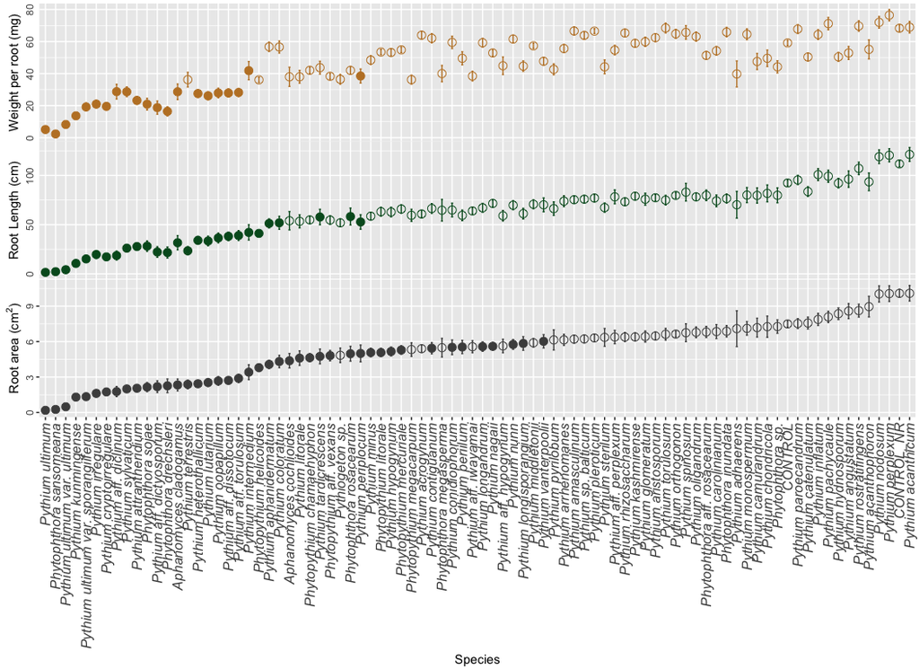

**Figure 7.** Phylogram for the ITS sequences of the rDNA for oomycete species found during the survey. Phylogenetic distribution of pathogenicity traits mapped to taxa represent in the tree. Tip colors indicate members of different clades. Parameters in light gray represent taxa not isolated in the study.

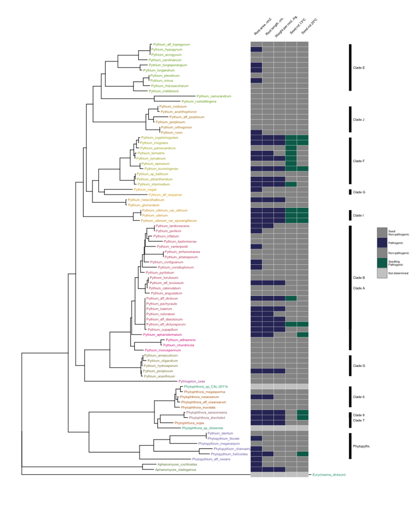

**Figure 8.** Prevalence of pathogenic oomycete species, designated based on seedling assay data, across the states sampled during the current study. Color gradient indicates number of isolates per species collected per state during 2011 and 2012.

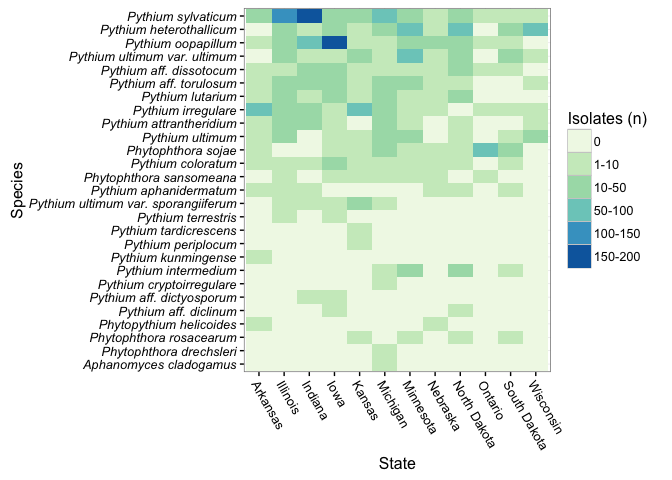

## Tables

**Table 1.** Mean disease severity index (DSI) of soybean cv. `Sloan` seeds in response to multiple oomycete species as compared to the non-inoculated control at 13ºC or 20ºC. Only species with significant differences from the control at either temperature are represented (Complete table, see Supplementary Table 2).  
A seed rot assay was used to determine pathogenicity of oomycete species using a disease severity scale of 0-4 to rate individual seeds. Data were transformed to disease severity index (0=non-pathogenic; 100=highly aggressive).

| Species | N | mean_DI13 | std_DI13 | Pval_13C | mean_DI20 | std_DI20 | Pval_20C |  |
| --- | --- | --- | --- | --- | --- | --- | --- | --- |
| Phytophthora drechsleri | 1 | 13.056 | 3.194 | 1.000 | 90.278 | 2.017 | 0.048 | NA |
| Phytophthora sansomeana | 2 | 58.889 | 10.007 | 1.000 | 94.722 | 1.308 | 0.004 | NA |
| Phytopythium helicoides | 2 | 22.500 | 1.896 | 1.000 | 91.944 | 1.611 | 0.004 | NA |
| Pythium aff. diclinum | 3 | 78.704 | 2.501 | 0.032 | 32.963 | 5.282 | 1.000 | NA |
| Pythium aff. dictyosporum | 2 | 93.333 | 1.143 | 0.006 | 85.139 | 4.223 | 0.017 | NA |
| Pythium aphanidermatum | 3 | 53.241 | 3.823 | 1.000 | 99.907 | 0.093 | 0.000 | NA |
| Pythium cryptoirregulare | 1 | 99.722 | 0.278 | 0.018 | 95.556 | 1.002 | 0.021 | NA |
| Pythium intermedium | 3 | 83.056 | 4.780 | 0.015 | 53.426 | 6.643 | 1.000 | NA |
| Pythium irregulare | 3 | 98.889 | 0.449 | 0.001 | 80.463 | 3.531 | 0.027 | NA |
| Pythium kunmingense | 2 | 100.000 | 0.000 | 0.002 | 89.306 | 1.496 | 0.007 | NA |
| Pythium paroecandrum | 3 | 93.981 | 1.636 | 0.002 | 49.259 | 4.369 | 1.000 | NA |
| Pythium spinosum | 3 | 80.556 | 4.118 | 0.023 | 44.722 | 6.999 | 1.000 | NA |
| Pythium sylvaticum | 3 | 99.444 | 0.244 | 0.001 | 74.444 | 2.636 | 0.083 | NA |
| Pythium terrestris | 1 | 99.167 | 0.589 | 0.021 | 77.778 | 3.422 | 0.270 | NA |
| Pythium ultimum | 3 | 99.167 | 0.298 | 0.001 | 99.259 | 0.322 | 0.000 | NA |
| Pythium ultimum var. sporangiiferum | 3 | 96.481 | 1.044 | 0.001 | 98.056 | 0.723 | 0.001 | NA |
| Pythium ultimum var. ultimum | 3 | 99.815 | 0.128 | 0.001 | 99.630 | 0.219 | 0.000 | NA |
| Control | NA | 2.579 | 0.310 | NA | 8.730 | 0.767 | NA |  |

| Species | N | mnv.p | ar | ar.se | ar.p | ln | ln.se | ln.p | wpr | wpr.se | wpr.p |
| --- | --- | --- | --- | --- | --- | --- | --- | --- | --- | --- | --- |
| Aphanomyces cladogamus | 9 | 0.000 | 2.330 | 0.503 | 0.000 | 31.646 | 7.178 | 0.002 | 28.667 | 4.853 | 0.044 |
| Aphanomyces cochlioides | 9 | 0.019 | 4.379 | 0.613 | 0.019 | 53.977 | 9.329 | 1.000 | 38.000 | 6.000 | 1.000 |
| Phytophthora drechsleri | 9 | 0.000 | 2.257 | 0.582 | 0.000 | 21.703 | 5.614 | 0.000 | 16.444 | 2.863 | 0.000 |
| Phytophthora rosacearum | 27 | 0.000 | 4.973 | 0.631 | 0.000 | 58.232 | 8.622 | 0.031 | 42.000 | 2.377 | 1.000 |
| Phytophthora sansomeana | 18 | 0.000 | 0.258 | 0.063 | 0.000 | 2.254 | 0.563 | 0.000 | 2.333 | 0.518 | 0.000 |
| Phytophthora sojae | 27 | 0.000 | 2.147 | 0.389 | 0.000 | 28.181 | 5.324 | 0.000 | 20.926 | 3.647 | 0.000 |
| Phytopythium aff. vexans | 18 | 0.001 | 4.813 | 0.442 | 0.001 | 54.681 | 4.386 | 0.388 | 38.333 | 1.955 | 0.587 |
| Phytopythium chamaehyphon | 27 | 0.000 | 4.637 | 0.346 | 0.000 | 54.824 | 3.552 | 0.163 | 42.074 | 2.074 | 1.000 |
| Phytopythium helicoides | 18 | 0.000 | 3.794 | 0.318 | 0.000 | 41.125 | 2.731 | 0.016 | 36.111 | 1.699 | 0.251 |
| Phytopythium litorale | 27 | 0.002 | 5.076 | 0.352 | 0.002 | 63.166 | 4.454 | 0.677 | 53.481 | 1.730 | 1.000 |
| Phytopythium mercuriale | 27 | 0.005 | 5.288 | 0.362 | 0.005 | 65.888 | 4.230 | 1.000 | 54.815 | 1.758 | 1.000 |
| Pythium aff. diclinum | 27 | 0.000 | 1.768 | 0.426 | 0.000 | 18.602 | 4.557 | 0.000 | 28.741 | 4.584 | 0.000 |
| Pythium aff. dictyosporum | 18 | 0.000 | 2.186 | 0.498 | 0.000 | 22.220 | 5.379 | 0.000 | 18.778 | 4.110 | 0.000 |
| Pythium aff. dissotocum | 27 | 0.000 | 2.715 | 0.301 | 0.000 | 38.133 | 4.282 | 0.000 | 27.926 | 2.545 | 0.000 |
| Pythium aff. torulosum | 27 | 0.000 | 2.889 | 0.352 | 0.000 | 38.977 | 5.004 | 0.000 | 28.222 | 2.536 | 0.000 |
| Pythium aphanidermatum | 27 | 0.000 | 4.073 | 0.350 | 0.000 | 51.256 | 4.599 | 0.016 | 56.741 | 2.906 | 1.000 |
| Pythium attrantheridium | 27 | 0.000 | 2.051 | 0.247 | 0.000 | 27.772 | 3.462 | 0.000 | 23.259 | 2.368 | 0.000 |
| Pythium coloratum | 27 | 0.000 | 4.316 | 0.521 | 0.000 | 51.893 | 6.566 | 0.003 | 56.593 | 3.759 | 1.000 |
| Pythium conidiophorum | 27 | 0.002 | 5.518 | 0.623 | 0.002 | 64.866 | 6.973 | 0.343 | 59.481 | 3.862 | 1.000 |
| Pythium contiguanum | 27 | 0.019 | 5.440 | 0.472 | 0.019 | 66.416 | 4.915 | 1.000 | 62.074 | 2.859 | 1.000 |
| Pythium cryptoirregulare | 9 | 0.000 | 1.740 | 0.215 | 0.000 | 17.280 | 2.335 | 0.000 | 19.556 | 2.375 | 0.000 |
| Pythium heterothallicum | 27 | 0.000 | 2.431 | 0.254 | 0.000 | 34.058 | 3.957 | 0.000 | 27.556 | 2.349 | 0.000 |
| Pythium hypogynum | 27 | 0.002 | 5.164 | 0.379 | 0.002 | 62.808 | 4.852 | 0.339 | 53.185 | 2.230 | 1.000 |
| Pythium intermedium | 27 | 0.000 | 3.410 | 0.632 | 0.000 | 42.129 | 7.779 | 0.000 | 41.852 | 5.690 | 0.000 |
| Pythium irregulare | 27 | 0.000 | 1.618 | 0.291 | 0.000 | 19.662 | 3.980 | 0.000 | 20.963 | 2.325 | 0.000 |
| Pythium kunmingense | 18 | 0.000 | 1.301 | 0.108 | 0.000 | 10.641 | 1.174 | 0.000 | 13.667 | 1.510 | 0.000 |
| Pythium litorale | 9 | 0.023 | 4.599 | 0.618 | 0.023 | 53.376 | 6.658 | 1.000 | 38.000 | 3.986 | 1.000 |
| Pythium longandrum | 27 | 0.049 | 5.578 | 0.401 | 0.049 | 67.096 | 4.512 | 1.000 | 59.259 | 2.697 | 1.000 |
| Pythium longisporangium | 27 | 0.004 | 5.844 | 0.578 | 0.004 | 61.178 | 5.407 | 0.139 | 44.667 | 3.257 | 0.894 |
| Pythium lutarium | 27 | 0.000 | 2.535 | 0.333 | 0.000 | 33.427 | 4.884 | 0.000 | 26.148 | 2.542 | 0.000 |
| Pythium minus | 27 | 0.001 | 5.075 | 0.365 | 0.001 | 58.632 | 3.784 | 0.451 | 48.444 | 2.731 | 1.000 |
| Pythium nagaii | 27 | 0.026 | 5.602 | 0.321 | 0.026 | 71.571 | 3.604 | 1.000 | 52.889 | 2.112 | 1.000 |
| Pythium nunn | 27 | 0.039 | 5.760 | 0.411 | 0.039 | 69.767 | 4.598 | 1.000 | 61.556 | 2.414 | 1.000 |
| Pythium oopapillum | 27 | 0.000 | 2.670 | 0.368 | 0.000 | 36.522 | 4.982 | 0.000 | 27.926 | 2.967 | 0.000 |
| Pythium periilum | 27 | 0.002 | 5.543 | 0.561 | 0.002 | 59.440 | 5.378 | 0.186 | 49.556 | 4.088 | 1.000 |
| Pythium periplocum | 27 | 0.000 | 4.998 | 0.716 | 0.000 | 52.741 | 7.378 | 0.000 | 38.489 | 4.391 | 0.003 |
| Pythium sylvaticum | 27 | 0.000 | 1.995 | 0.241 | 0.000 | 26.115 | 3.424 | 0.000 | 28.667 | 3.027 | 0.000 |
| Pythium tardicrescens | 27 | 0.000 | 4.745 | 0.629 | 0.000 | 57.746 | 7.890 | 0.001 | 43.704 | 4.007 | 0.104 |
| Pythium terrestris | 9 | 0.000 | 2.379 | 0.368 | 0.000 | 23.475 | 4.138 | 0.000 | 36.222 | 4.576 | 1.000 |
| Pythium ultimum | 27 | 0.000 | 0.183 | 0.039 | 0.000 | 1.539 | 0.431 | 0.000 | 5.111 | 1.397 | 0.000 |
| Pythium ultimum var. sporangiiferum | 27 | 0.000 | 1.337 | 0.240 | 0.000 | 15.196 | 3.169 | 0.000 | 19.200 | 2.497 | 0.000 |
| Pythium ultimum var. ultimum | 27 | 0.000 | 0.481 | 0.070 | 0.000 | 4.228 | 0.738 | 0.000 | 8.256 | 1.252 | 0.000 |
| Pythium vanterpoolii | 27 | 0.022 | 6.023 | 0.567 | 0.022 | 70.135 | 7.034 | 1.000 | 47.704 | 2.306 | 1.000 |

## Supplementary figures

**Supplementary Figure 1.** Comparison of the non-inoculated controls and inoculated seedlings with the 84 oomycete species combined for the four parameters measured: (A) root area (cm2), (B) root length (cm), (C) weight per root (mg), and (D) weight per shoot (mg). Boxplot represent distribution of data, the line represents the median for each group and dots indicates outliers.

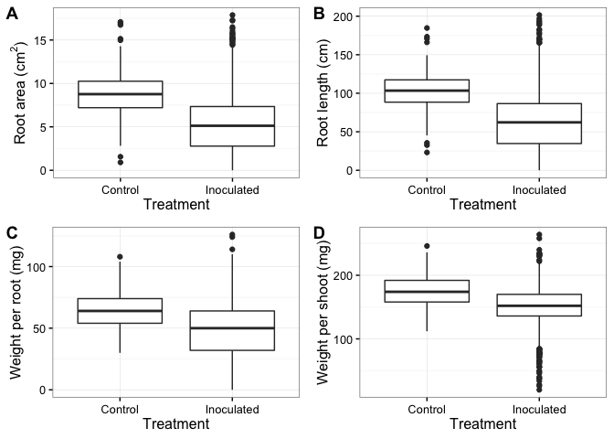

**Supplementary Figure 2.** Principal Component Analysis (PCA) on seedling parameters measured to determine correlation and contribution for the evaluation pathogenic/non-pathogenic oomycete species. The values on parenthesis indicate the percent of variance explained by the respective axis. The length and the direction of the vectors indicate the contribution of each parameter to the corresponding variance.

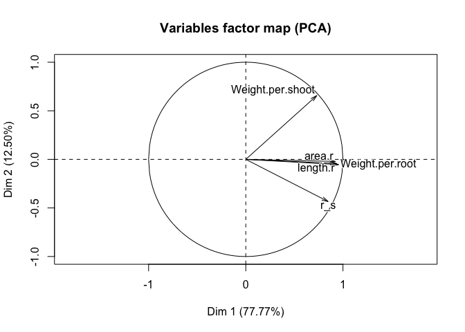

**Supplementary Figure 3.** Distribution of parameters analyzed: (A) root area (cm2), (B) root length (cm), and (C) weight per root (mg), on three groups based on the significance of the MANOVA and univariate analysis: group 1 (non-significant for all analyses), group 2 (significant for MANOVA, but not for all univariate analyses), group 3 (significant for both MANOVA and univariate analyses). Boxplot represent distribution of data, the line represents the median for each group and dots indicates outliers.

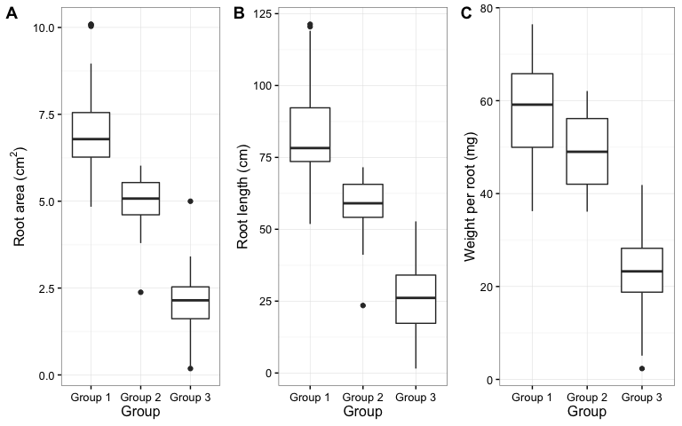

**Supplementary Figure 4.** Effect of media on the frequency of recovery of oomycete species summarized by clade in 2012. Numbers at the end of the bar represent number of total isolates per clade.

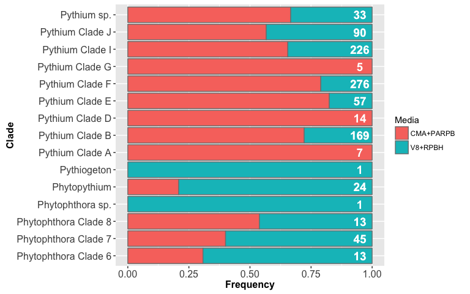